# Eviden EDA and Modeling

This notebooks aims to classify company statements such as mission, vision, strategy, goals and core values using prelabeled dataset. First a basic eda is done to understand the data. Then two models are used: rule based baseline and TF-IDF and logistic regression classifier. Both models are evaluated using precision, recall and f1 score and the two models are then compared.

## Importing Libraries

Importing all the necessary tools for data handling, preprocessing, model training and evaluation.

```python
import pandas as pd
import re
from sklearn.model_selection import train_test_split
from sklearn.feature_extraction.text import TfidfVectorizer
from sklearn.linear_model import LogisticRegression
from sklearn.metrics import classification_report, confusion_matrix
from sklearn.metrics import classification_report, accuracy_score, f1_score
import seaborn as sns
import matplotlib.pyplot as plt
from collections import Counter
from langdetect import detect
import nltk
from nltk.corpus import stopwords
```

## Load the data

Load the dataset and visualise the data stucture and number of statements per category.

```python
df = pd.read_csv("/Users/aadira/Downloads/evidendata.csv")

display(df.head())
print(df["Type"].value_counts())
```

|  | Company | Statement | Type |
| --- | --- | --- | --- |
| 0 | advanced micro device | Build great products that accelerate next-gene... | mission |
| 1 | advanced micro device | To be a driver of computing innovation by maki... | vision |
| 2 | advanced micro device | To have quality leadership that promotes a cul... | vision |
| 3 | advanced micro device | Diversity (in respects to gender, ethnicity an... | core value |
| 4 | advanced micro device | Respect (In regards to all relationships; hori... | core value |

```
Type
strategy      116
goal           88
core value     84
vision         46
mission        21
steategy        1
mission         1
core alue       1
Goals           1
Vision          1
Name: count, dtype: int64
```

## Cleaning and normalizing categories

This step is done to standardize inconsistant categories to ensure clean consistant data.

```python
df.columns = df.columns.str.strip().str.lower()
df = df.rename(columns={"statement": "text", "type": "label"})

df["label"] = df["label"].str.lower().str.strip()
df["label"] = df["label"].replace({
    "goal": "goals",
    "goals": "goals",
    "mission": "mission",
    "vision": "vision",
    "core alue": "core value",
    "core value": "core value",
    "strategy": "strategy",
    "steategy": "strategy"
})

df = df.dropna(subset=["text", "label"])
print("Labels:", df["label"].unique(),df["label"].value_counts() )
```

```
Labels: ['mission' 'vision' 'core value' 'goals' 'strategy'] label
strategy      117
goals          89
core value     85
vision         47
mission        22
Name: count, dtype: int64
```

## Class distribution

This is done to visualize the differences in the types anf the imbalances.

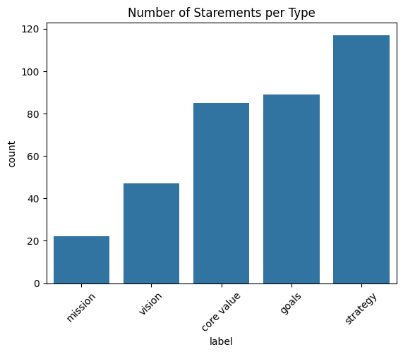

```python
sns.countplot(x=df["label"].str.lower())
plt.title("Number of Starements per Type")
plt.xticks(rotation=45)
plt.show()
```

## Data cleaning

Remove puctuation al lowercases all the text for normaization and removed stopwords to have a better top worrds list.

```python
def clean_text(text):
    text = text.lower()
    text = re.sub(r"[^\w\s]", "", text)
    return text


df["clean_text"] = df["text"].apply(clean_text)

stop_words = set(stopwords.words('english')) | set(stopwords.words('dutch'))
def clean_text(text):
    text = str(text).lower()
    text = re.sub(r'[^a-zA-Záéíóúüäöëïçàèìòùâêîôû]+', ' ', text)
    tokens = [w for w in text.split() if w not in stop_words and len(w) > 2]
    return tokens

df["tokens"] = df["text"].apply(clean_text)
```

## Detect Language

This is done because there are both dutch and english statements and are processed differently

```python
def detect_lang_safe(text):
    try:
        return detect(str(text))
    except:
        return "unknown"

df["lang"] = df["text"].apply(detect_lang_safe)

data = df[df["lang"].isin(["en","nl"])]
print(data["lang"].value_counts())
```

```
lang
en    198
nl    128
Name: count, dtype: int64
```

## Top words per type

This is done to understand the top words per type and language with will be further used for the keywords for the baseline

```python
def top_words_by_label_lang(df, label, lang_code, n=10):
    subset = df[(df["label"] == label) & (df["lang"] == lang_code)]
    all_words = [word for tokens in subset["tokens"] for word in tokens]
    word_counts = Counter(all_words)
    return word_counts.most_common(n)

labels = df["label"].unique()
languages = ["en", "nl"]

for lang in languages:
    print(f"\nStatement counts for {lang}:")
    print(df[df["lang"]==lang]["label"].value_counts())
    print(f"\nTop words in {lang} per type:")
    for label in labels:
        top_words = top_words_by_label_lang(df, label, lang)
        print(f"{label}: {', '.join([w[0] for w in top_words])}")
```

```
Statement counts for en:
label
strategy      65
core value    54
goals         43
vision        24
mission       12
Name: count, dtype: int64

Top words in en per type:
mission: people, great, every, build, software, environment, together, everyone, fit, feel
vision: customers, make, innovation, world, processes, aim, fitness, vision, new, computing
core value: coolblue, customers, take, always, way, change, open, right, value, core
goals: people, products, sustainable, new, healthy, cloud, reduce, contribution, improve, health
strategy: lvnl, new, air, customers, aviation, partners, traffic, organization, focus, performance

Statement counts for nl:
label
strategy      43
goals         41
vision        21
core value    13
mission       10
Name: count, dtype: int64

Top words in nl per type:
mission: water, onze, maatschappelijke, belangrijke, stad, levert, rol, samen, bieden, diensten
vision: onze, wij, klanten, amsterdam, mensen, willen, woningmarkt, initiatieven, basis, key
core value: onze, key, werken, ruimte, basis, krijgen, manier, waarop, wij, eigen
goals: mogelijk, isc, kosten, aantal, ict, alle, maatschappelijke, kadaster, zodat, oog
strategy: onze, key, eigen, duurzame, digitalisering, willen, vermogen, wij, daeb, alleen
```

## Baseline

Create a simple rule-based classifier using keywords. This serves as a baseline to benchmark the TF-IDF and logistic regression classifier.

Overall for english the accuracy is low at about 16 percent because just keyword matching is not able to recognize context. Some classeshave a decent precision but poor recall like core value meaning many statements were missed. Weighted f1 is 0.23, reflecting overall limited effectiveness.

For dutch the overall accuracy is even lover at about 14 percent. Some labels have a moderate recall, but most classes are predicted incorrectly. Weighted f1 is 0.15.

Overall it can be determined that a basic keyword classifier is nor effective in clasifing the statements and while it can be improved with more specific keyword that risk overfitting for this dataset.

```python
def keyword_baseline_bilingual(text):
    text = text.lower()

    if any(w in text for w in ["mission", "purpose", "serve", "build", "missie", "doel","belangrijke","rol"]):
        return "mission"

    elif any(w in text for w in ["vision", "future", "aspire", "aim", "visie", "toekomst","willen","nitiatieven"]):
        return "vision"

    elif any(w in text for w in ["goal", "target", "objective","contribution", "doel", "doelen"]):
        return "goals"

    elif any(w in text for w in ["core value", "respect","open", "teamwork", "kernwaarde", "waardes", "werken",]):
        return "core value"

    elif any(w in text for w in ["strategy", "plan", "approach","focus", "strategie", "aanpak","willen"]):
        return "strategy"
    else:
        return "unknown"

df["baseline"] = df["text"].apply(keyword_baseline_bilingual)



print("Baseline Performance: English")
en_data = df[df["lang"] == "en"]
print(classification_report(en_data["label"], en_data["baseline"], zero_division=0))


print("\nBaseline Performance: Dutch")
nl_data = df[df["lang"] == "nl"]
print(classification_report(nl_data["label"], nl_data["baseline"], zero_division=0))
```

```
Baseline Performance: English
              precision    recall  f1-score   support

  core value       0.75      0.22      0.34        54
       goals       0.80      0.09      0.17        43
     mission       0.13      0.33      0.19        12
    strategy       0.62      0.12      0.21        65
     unknown       0.00      0.00      0.00         0
      vision       0.60      0.12      0.21        24

    accuracy                           0.16       198
   macro avg       0.48      0.15      0.19       198
weighted avg       0.66      0.16      0.23       198


Baseline Performance: Dutch
              precision    recall  f1-score   support

  core value       0.45      0.38      0.42        13
       goals       0.00      0.00      0.00        41
     mission       0.31      0.50      0.38        10
    strategy       0.67      0.05      0.09        43
     unknown       0.00      0.00      0.00         0
      vision       0.38      0.29      0.32        21

    accuracy                           0.14       128
   macro avg       0.30      0.20      0.20       128
weighted avg       0.36      0.14      0.15       128
```

```python
summary_baseline = pd.DataFrame({
    "Language": ["English", "Dutch"],
    "Accuracy": [
        accuracy_score(en_data["label"], en_data["baseline"]),
        accuracy_score(nl_data["label"], nl_data["baseline"])
    ],
    "Macro F1": [
        f1_score(en_data["label"], en_data["baseline"], average="macro"),
        f1_score(nl_data["label"], nl_data["baseline"], average="macro")
    ],
    "Weighted F1": [
        f1_score(en_data["label"], en_data["baseline"], average="weighted"),
        f1_score(nl_data["label"], nl_data["baseline"], average="weighted")
    ]
}).round(3)

print(summary_baseline)
```

```
  Language  Accuracy  Macro F1  Weighted F1
0  English     0.157     0.185        0.234
1    Dutch     0.141     0.202        0.155
```

## Training and test split

Preparing the data for training using the cleaned tokens. It is split into dutch and english to handle the languages separately. Training is on 80 percent and tesing on 20 percent of the data

```python
df["clean_text_for_tfidf"] = df["tokens"].apply(lambda x: " ".join(x))

en_data = df[df["lang"] == "en"]
nl_data = df[df["lang"] == "nl"]

X_train_en, X_test_en, y_train_en, y_test_en = train_test_split(
    en_data["clean_text_for_tfidf"], en_data["label"], test_size=0.2, random_state=42, stratify=en_data["label"]
)

X_train_nl, X_test_nl, y_train_nl, y_test_nl = train_test_split(
    nl_data["clean_text_for_tfidf"], nl_data["label"], test_size=0.2, random_state=42, stratify=nl_data["label"]
)
```

## Train TF-IDF + Logistic Regression

TF-IDF is used to turn text into numeric statistic to reflect the significance of a word. Using this to highlight keywords within the statement types. Logistic regression will learn the patterns of where these words are used to then seperate it into its types. We will use precision, recall and f1 score to measure the accuracy.

For english the overall accuracy is about 53 percent. Classes like core value and strategy are predicted well, with high recall for strategy. However, small classes like mission and vision are still poorly captured due to lower number of statements.

The accuracy for dutch is 46 percent, with better recall for goals. Classes like core value, mission, and vision perform poorly, because of limited training data.

Overall this is better than the basline and can be improved with more data as a starting point.

```python
def train_logreg_tfidf(X_train, y_train, X_test, y_test):
    vectorizer = TfidfVectorizer(max_features=2000, ngram_range=(1,2))
    X_train_tfidf = vectorizer.fit_transform(X_train)
    X_test_tfidf = vectorizer.transform(X_test)

    clf = LogisticRegression(max_iter=1000)
    clf.fit(X_train_tfidf, y_train)
    y_pred = clf.predict(X_test_tfidf)

    report = classification_report(y_test, y_pred, output_dict=True, zero_division=0)
    return clf, vectorizer, report, y_pred

clf_en, vec_en, report_en, y_pred_en = train_logreg_tfidf(X_train_en, y_train_en, X_test_en, y_test_en)

clf_nl, vec_nl, report_nl, y_pred_nl = train_logreg_tfidf(X_train_nl, y_train_nl, X_test_nl, y_test_nl)

print("Logistic regression for english")
print(classification_report(y_test_en, y_pred_en, zero_division=0))

print("Logistic regression for dutch")
print(classification_report(y_test_nl, y_pred_nl, zero_division=0))
```

```
Logistic regression for english
              precision    recall  f1-score   support

  core value       0.80      0.73      0.76        11
       goals       0.50      0.11      0.18         9
     mission       0.00      0.00      0.00         2
    strategy       0.43      0.92      0.59        13
      vision       0.00      0.00      0.00         5

    accuracy                           0.53        40
   macro avg       0.35      0.35      0.31        40
weighted avg       0.47      0.53      0.44        40

Logistic regression for dutch
              precision    recall  f1-score   support

  core value       0.00      0.00      0.00         3
       goals       0.41      0.88      0.56         8
     mission       0.00      0.00      0.00         2
    strategy       0.56      0.56      0.56         9
      vision       0.00      0.00      0.00         4

    accuracy                           0.46        26
   macro avg       0.19      0.29      0.22        26
weighted avg       0.32      0.46      0.36        26
```

## Results summary

The evaluation table shows the keyword-based baseline and a TF-IDF and logistic regression classifier. The baseline has low accuracy at about 16 percent in english and 14 percent in dutch. This is because it focuses only on keywords and not conext in the statements. In comparison, the TF-IDF and logistic regression classifier has about a 53 percent accuracy for english and 46 percent for dutch and also higher weighted f1 scores of 0.44 in english and and 0.37 in dutch.

Overall, the table confirms that using a model trained on TF-IDF features is more effective than a rule-based approach for classifying company statements.

```python
results_bilingual = pd.DataFrame({
    "Model": ["Keyword Baseline (EN)", "Keyword Baseline (NL)",
              "TF-IDF + LogReg (EN)", "TF-IDF + LogReg (NL)"],
    "Accuracy": [
        summary_baseline.loc[0, "Accuracy"],
        summary_baseline.loc[1, "Accuracy"],
        report_en["accuracy"],
        report_nl["accuracy"]
    ],
    "Macro F1": [
        summary_baseline.loc[0, "Macro F1"],
        summary_baseline.loc[1, "Macro F1"],
        report_en["macro avg"]["f1-score"],
        report_nl["macro avg"]["f1-score"]
    ],
    "Weighted F1": [
        summary_baseline.loc[0, "Weighted F1"],
        summary_baseline.loc[1, "Weighted F1"],
        report_en["weighted avg"]["f1-score"],
        report_nl["weighted avg"]["f1-score"]
    ]
}).round(3)

display(results_bilingual)
```

|  | Model | Accuracy | Macro F1 | Weighted F1 |
| --- | --- | --- | --- | --- |
| 0 | Keyword Baseline (EN) | 0.157 | 0.185 | 0.234 |
| 1 | Keyword Baseline (NL) | 0.141 | 0.202 | 0.155 |
| 2 | TF-IDF + LogReg (EN) | 0.525 | 0.306 | 0.441 |
| 3 | TF-IDF + LogReg (NL) | 0.462 | 0.223 | 0.365 |

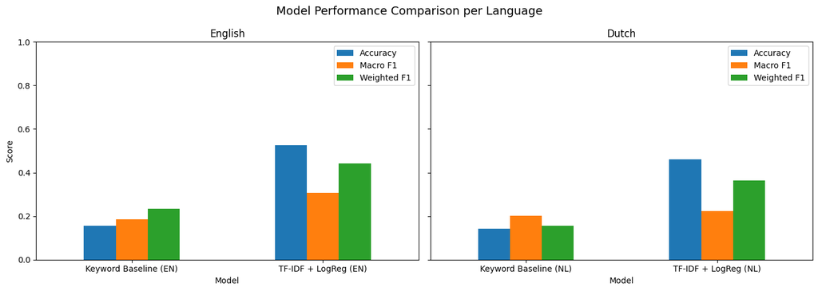

```python
results_en = results_bilingual[results_bilingual["Model"].str.contains("EN", case=False)]
results_nl = results_bilingual[results_bilingual["Model"].str.contains("NL", case=False)]

fig, axes = plt.subplots(1, 2, figsize=(14, 5), sharey=True)

results_en.set_index("Model")[["Accuracy", "Macro F1", "Weighted F1"]].plot(
    kind="bar", ax=axes[0], rot=0, title="English"
)
results_nl.set_index("Model")[["Accuracy", "Macro F1", "Weighted F1"]].plot(
    kind="bar", ax=axes[1], rot=0, title="Dutch"
)

axes[0].set_ylabel("Score")
axes[0].set_ylim(0, 1)
plt.suptitle("Model Performance Comparison per Language", fontsize=14)
plt.tight_layout()
plt.show()
```

```python
for lang in ["en", "nl"]:
    print(f"Example Predictions for {lang.upper()} Statements")

    examples = df[df["lang"] == lang].sample(3, random_state=42)[["text", "label", "baseline"]]

    if lang == "en":
        examples["logreg_pred"] = clf_en.predict(vec_en.transform(examples["text"]))
    else:
        examples["logreg_pred"] = clf_nl.predict(vec_nl.transform(examples["text"]))

    display(examples[["text","label","baseline","logreg_pred"]])
```

```
Example Predictions for EN Statements
```

|  | text | label | baseline | logreg_pred |
| --- | --- | --- | --- | --- |
| 155 | Inclusion: “building and developing empathetic... | core value | mission | core value |
| 227 | Continuous transformation and modernisation of... | strategy | unknown | strategy |
| 17 | Think in standards | vision | unknown | core value |

```
Example Predictions for NL Statements
```

|  | text | label | baseline | logreg_pred |
| --- | --- | --- | --- | --- |
| 128 | De Key maakt vernieuwing mogelijk door haar ve... | strategy | unknown | strategy |
| 112 | We streven naar een dynamisch evenwicht van de... | goals | core value | goals |
| 80 | Maatschappelijk | core value | unknown | strategy |